# Exercise 5_1: Raster stack with terra

Advanced Geospatial Data Processing for Social Scientists

Author

Dennis Abel & Stefan Jünger

### Exercises

Building on our previous mapping exercise with Texas data, we want to continue to work with that region. Our aim is to create a raster stack (`SpatRaster`) for Texas population data between 2017 and 2020.

**Note🏋️ Exercise 1**

Load the four population raster layers for Texas 2017-2020 (`./data/worldpop/US-TX_ppp_2017_1km.tif`-`./data/worldpop/US-TX_ppp_2020_1km.tif`) with `terra::rast()` and integrate these into one raster stack. Either do this in two steps or by creating a file list and directly read these GeoTiffs as a stack.

**Note🏋️ Exercise 2**

Adjust the variable names (`names()`) and time (`time()`) of the raster stack.

**Note🏋️ Exercise 3**

Similar to the previous exercise, let’s reproject our Texas data to EPSG:3081.

**Note🏋️ Exercise 4**

Visualize all four years with a spatial window of `x = 0:1000` and `y = 0:1000`.

**Note🏋️ Exercise 5**

Export your `SpatRaster` with `writeRaster()` as GeoTiff to your local storage.

### Solutions

**Tip✅ Solution 1**

```r
library(dplyr)
library(ggplot2)
library(terra)
library(tidyterra)
# Load the raster data
files <- list.files("./data/worldpop", pattern = "US-TX_ppp_20(17|18|19|20)_1km\\.tif$", full.names = TRUE)

TX_pop_stack <- terra::rast(files)

TX_pop_stack
```

```
class       : SpatRaster
size        : 1279, 1575, 4  (nrow, ncol, nlyr)
resolution  : 0.008333333, 0.008333333  (x, y)
extent      : -106.6429, -93.51792, 25.84125, 36.49958  (xmin, xmax, ymin, ymax)
coord. ref. : lon/lat WGS 84 (EPSG:4326)
sources     : US-TX_ppp_2017_1km.tif
              US-TX_ppp_2018_1km.tif
              US-TX_ppp_2019_1km.tif
              US-TX_ppp_2020_1km.tif
names       : US-TX_p~017_1km, US-TX_p~018_1km, US-TX_p~019_1km, US-TX_p~020_1km
```

**Tip✅ Solution 2**

```r
# Adjust variable time
layer_years <- c(2017:2020)
time(TX_pop_stack, tstep = "years") <- layer_years

# Adjust variable name
names(TX_pop_stack) <- paste0("pop_", layer_years)

print(TX_pop_stack)
```

```
class       : SpatRaster
size        : 1279, 1575, 4  (nrow, ncol, nlyr)
resolution  : 0.008333333, 0.008333333  (x, y)
extent      : -106.6429, -93.51792, 25.84125, 36.49958  (xmin, xmax, ymin, ymax)
coord. ref. : lon/lat WGS 84 (EPSG:4326)
sources     : US-TX_ppp_2017_1km.tif
              US-TX_ppp_2018_1km.tif
              US-TX_ppp_2019_1km.tif
              US-TX_ppp_2020_1km.tif
names       : pop_2017, pop_2018, pop_2019, pop_2020
time (years): 2017 to 2020 (4 steps)
```

**Tip✅ Solution 3**

```r
TX_pop_stack <- terra::project(TX_pop_stack, "EPSG:3081")
```

**Tip✅ Solution 4**

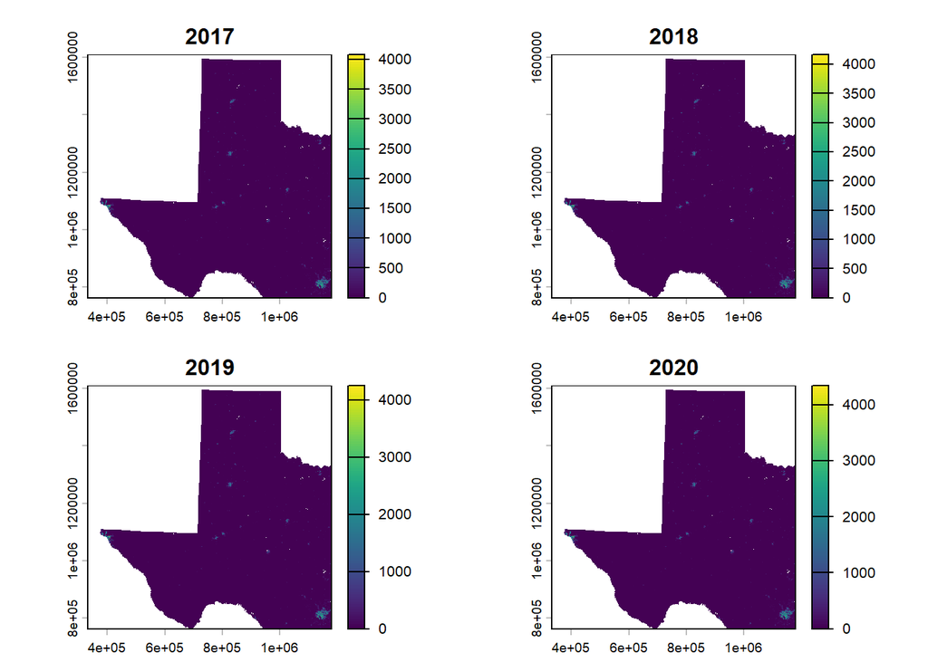

```r
# Plot a single layer
terra::plot(TX_pop_stack[0:1000,
                         0:1000,
                         1:4,
                         drop = FALSE])
```

**Tip✅ Solution 5**

```r
# Export
writeRaster(
  TX_pop_stack,
  "./data/stacks/TX_pop_stack.tif",
  overwrite=TRUE,
  gdal=c("COMPRESS=LZW","BIGTIFF=YES")
)
```